# Wetland inter-comparison

Sam Chamberlain

```r
knitr::opts_knit$set(root.dir = normalizePath("../"))
```

This .rmd goes step-by-step through the analysis used in Sam Chamberlain’s wetland methane flux intercomparison. All analysis completed within R is reproducible within this document; however, model hypothesis testing and information theory analysis was conducted in MATLAB. The MATLAB analyses are not directly reproducible from this document, but links to MATLAB scripts are provide along with instructions to repeat those analyses. Otherwise, all statistics, figures, and tables will be recreated within this script.

## Loading packages

```r
library(knitr); library(tidyverse); library(lubridate); library(plotly); library(zoo); library(devtools); library(gridExtra); library(scales)

knitr::opts_knit$get("root.dir")
```

```
## [1] "/Users/samchamberlain/Rdir/WetlandComparison"
```

## Data processing to daily and yearly fluxes

In the following *_processing.R* files, half-hourly flux and met files for all sites are merged and processed into daily and yearly fluxes. Each *.R* contains an identical script re-run for each site, where the input met variables (temp probe depths) vary across sites. All processing relies on *tidyverse* package.

```r
#load and process data into half-hourly, daily, and annual sums
source("R/peat19_processing.R") #19yr old peat site
source("R/peat6_processing.R") #6yr old peat site
source("R/alluvium_processing.R") #alluvium site
```

Now we can combine the individual files into single sets with all data indexed by site.

```r
#merge daily sums to single dataset
all_daily <- rbind(peat19_daily, peat6_daily); all_daily <- rbind(all_daily, alluvium_daily)

#For annual fluxes we will do a bit more processing...
#add age of wetland variable
peat19_yearly$age <- peat19_yearly$year - 1997
peat6_yearly$age <- peat6_yearly$year - 2011
alluvium_yearly$age <- alluvium_yearly$year - 2014

#remove year with draw down disturbance at old peat site to compare stable states only
peat19_yearly <- subset(peat19_yearly, year != 2013)

#merge to single dataset
all_annual <- rbind(peat19_yearly, peat6_yearly); all_sites <- rbind(all_annual, alluvium_yearly)

#remove incomplete years
all_annual <- subset(all_annual, Days >= 365)
```

# Analysis and figures

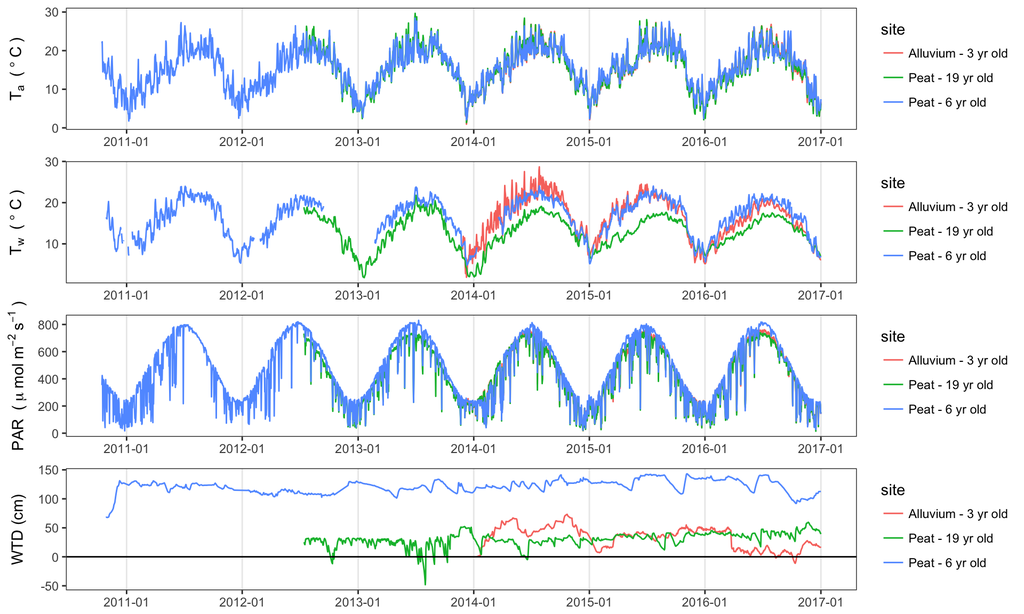

Fig. 1: Meteorological variables across core sites

Daily time series for dominant met drivers (**Tair**, **Tw**, **PAR**, **WTD**) across the three core sites. Atmospheric drivers (**Tair** and **PAR**) are equivalent across sites. The old peat site experienced some water table drops early on, but otherwise the sites are consistently inundated. Water temperature (**Tw**) is lower at the old peat site due to differences in site structure explained in more detail in *Eichelmann et al. in review*.

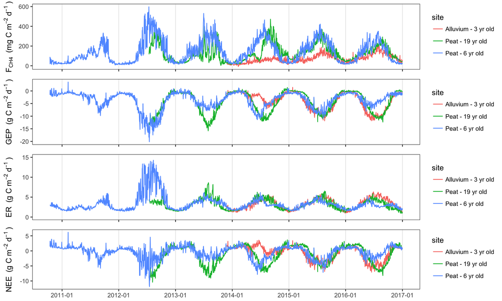

Fig. 2: Daily CH4, GEP, ER, and NEE fluxes across wetland core sites

Daily **NEE** fluxes are quite similar across sites, including the partitioned **GEP** and **ER** fluxes. However, daily **F_CH4** are notably lower at the alluvium site, despite the fact that it has similar magnitude photosynthetic input to the old peat site (Fig. 2), and by 2016, much larger photosynthetic input than the young peat site (Fig. 2). This observation displays a clear disconnect between recent photosynthetic input and wetland **F_CH4**. Additionally, the trajectory post-restoration of the recently restored peat and alluvium sites are notably divergent (Fig. 3). CH_4 fluxes are largest 1 year post-restoration and reduce with time, whereas the alluvium site fluxes gradually increase with time but are much lower than the peat site **F_CH4** (Fig. 3 below).

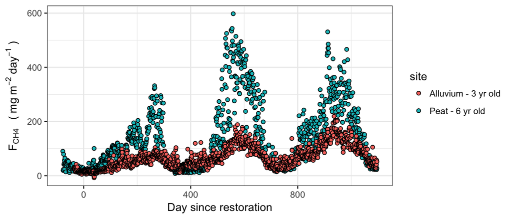

Fig. 3: Daily CH4 fluxes following restoration for alluvium and peat sites restored within the last six years

## Annual flux comparisons

For annual budget analysis, we first combine the yearly datasets into a single dataframe from which we can estimate mean annual fluxes and complete cross-site comparisons. Below are the mean annual fluxes with standard deviations.

Mean annual fluxes and site years

| site | NEE | sdNEE | CH4 | sdCH4 | GEP | sdGEP | ER | sdER | GHG | sdGHG | sites_years |
| --- | --- | --- | --- | --- | --- | --- | --- | --- | --- | --- | --- |
| Alluvium - 3 yr old | -279.0640 | 466.21214 | 26.00065 | 9.188659 | -1476.727 | 565.3867 | 1197.663 | 112.32912 | -156.5462 | 1428.8368 | 3 |
| Peat - 19 yr old | -350.8504 | 92.15823 | 50.62602 | 3.995548 | -1477.290 | 78.3980 | 1126.439 | 44.16596 | 401.0827 | 470.8632 | 3 |
| Peat - 6 yr old | -196.4093 | 193.85027 | 53.10636 | 10.586877 | -1406.741 | 502.4150 | 1210.331 | 351.96081 | 1050.0445 | 521.7299 | 6 |

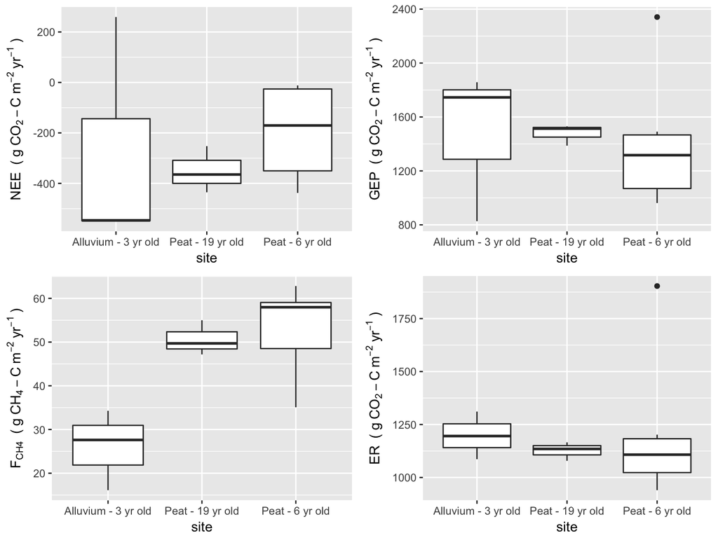

Fig. 4: Annual wetland flux comparisons

# Significance testing

There is considerable overlap in the mean annual **NEE**, **GEP**, and **ER** fluxes across all three sites. Looking at the statistics below, the only significant difference across sites exists for CH_4 fluxes, and for CH_4 fluxes, the annual fluxes from the alluvium site are significantly lower than either peat site, yet the peat sites are not significantly different from one another (see *TukeyHSD* comparison)

```r
NEE <- aov(all_sites$tNEE ~ all_sites$site); summary(NEE)
```

```
##                Df Sum Sq Mean Sq F value Pr(>F)
## all_sites$site  2  49891   24945   0.351  0.713
## Residuals       9 639583   71065
```

```r
GPP <- aov(all_sites$tGEP ~ all_sites$site); summary(GPP)
```

```
##                Df  Sum Sq Mean Sq F value Pr(>F)
## all_sites$site  2   14813    7407   0.035  0.966
## Residuals       9 1913721  212636
```

```r
ER <- aov(all_sites$tER ~ all_sites$site); summary(ER)
```

```
##                Df Sum Sq Mean Sq F value Pr(>F)
## all_sites$site  2  14602    7301   0.101  0.905
## Residuals       9 648519   72058
```

```r
CH4 <- aov(all_sites$tCH4 ~ all_sites$site); summary(CH4)
```

```
##                Df Sum Sq Mean Sq F value  Pr(>F)
## all_sites$site  2 1566.1   783.1   9.258 0.00654 **
## Residuals       9  761.2    84.6
## ---
## Signif. codes:  0 '***' 0.001 '**' 0.01 '*' 0.05 '.' 0.1 ' ' 1
```

```r
TukeyHSD(CH4)
```

```
##   Tukey multiple comparisons of means
##     95% family-wise confidence level
##
## Fit: aov(formula = all_sites$tCH4 ~ all_sites$site)
##
## $`all_sites$site`
##                                           diff        lwr      upr
## Peat - 19 yr old-Alluvium - 3 yr old 24.625372   3.660161 45.59058
## Peat - 6 yr old-Alluvium - 3 yr old  27.105711   8.949305 45.26212
## Peat - 6 yr old-Peat - 19 yr old      2.480339 -15.676067 20.63674
##                                          p adj
## Peat - 19 yr old-Alluvium - 3 yr old 0.0234213
## Peat - 6 yr old-Alluvium - 3 yr old  0.0061422
## Peat - 6 yr old-Peat - 19 yr old     0.9236054
```